# Sea surface temperature trend in the Gulf of California

The trend is the average change in sea surface temperature for each marine OHI region, in degrees Celsius per year. Yearly means from 2000 through 2025 are fit with

temperature = intercept + (trend × year) + (El Niño term × Oceanic Niño Index)

The Oceanic Niño Index is positive in El Niño years and negative in La Niña years, so one term takes out both. The saved trend is the slope on year from that fit. A second slope, fit to year alone, is drawn on the same figure. The rise is that slope times 25 years.

The pressure divides the rise since 2000 by 1°C. A rise of 1°C scores 1. A larger rise stays at 1, and a cooling stays at 0. The saved pressure table has one row per region, and the year on every row is 2025.

One degree of sea-surface warming is the further rise associated with the world reaching 2°C of global warming, the higher end of the Paris Agreement. Cael and coauthors compared 1982–2020 with the decades centered on that 2°C level in 14 climate models. Global mean sea-surface temperature rises 0.91°C in that comparison, and the annual maximum rises 1.07°C. Almost all of the rise in the maximum is the rise in the mean. The reference used here rounds that mean rise to 1°C. The paper is Cael, B. B., Burger, F. A., Henson, S. A., Britten, G. L., and Frölicher, T. L. (2024), Historical and future maximum sea surface temperatures, *Science Advances* 10, eadj5569, https://doi.org/10.1126/sciadv.adj5569.

The temperatures are monthly means supplied as `sst_monthly_pft_grid_2000_2025.nc`. The notes that came with the file are below.

The grid has 312 months, January 2000 through December 2025, on 432 rows of latitude and 360 columns of longitude. The latitude runs from about 18°N to 36°N and the longitude from about 117°W to 102°W, so the Gulf sits inside the grid with a margin. Temperature is in degrees Celsius. Empty cells on land are missing values.

The source is the Copernicus Marine Service reprocessed OSTIA analysis from the UK Met Office. The product is `SST_GLO_SST_L4_REP_OBSERVATIONS_010_011`, dataset `METOFFICE-GLO-SST-L4-REP-OBS-SST`, version `202003`, variable `analysed_sst`. The original fields are daily and gap-free at 0.05°. Daily values were converted from kelvin to °C by subtracting 273.15, averaged over each calendar month, and bilinearly interpolated onto the 4 km plankton grid (`cmems_obs-oc_glo_bgc-plankton_my_l3-multi-4km_P1D`). The month is stamped on the first day of the month.

```r
library(terra)
library(sf)
library(tidyverse)
library(exactextractr)
library(knitr)
sf_use_s2(FALSE)
```

```
## Spherical geometry (s2) switched off
```

```r
knitr::opts_chunk$set(fig.width = 8, fig.height = 6, message = FALSE, warning = FALSE)

nc_path <- "/home/shares/ohi/OHI_GOC/_raw_data/SST_Ricardo/sst_monthly_pft_grid_2000_2025.nc"
rgn_path <- "/home/shares/ohi/OHI_GOC/spatial/OHI_regions/goc_ohi_rgns.shp"
out_dir <- "/home/frazier/ohi_goc_prep/_pressures/prs_sst/v2025/output"
dir.create(out_dir, showWarnings = FALSE, recursive = TRUE)

score_year <- 2025
```

## 1. Monthly temperature

Land cells are stored as NaN. They are set to missing so later averages skip them.

```r
monthly <- rast(nc_path)
if (crs(monthly) == "") crs(monthly) <- "EPSG:4326"
monthly <- ifel(is.nan(monthly), NA, monthly)

if (is.null(time(monthly)) || any(is.na(time(monthly)))) {
  time(monthly) <- seq(as.Date("2000-01-01"), by = "month", length.out = nlyr(monthly))
}
names(monthly) <- format(time(monthly), "%Y-%m")

range(time(monthly))
```

```
## [1] "2000-01-01" "2025-12-01"
```

```r
nlyr(monthly)
```

```
## [1] 312
```

```r
res(monthly)
```

```
## [1] 0.04166667 0.04166666
```

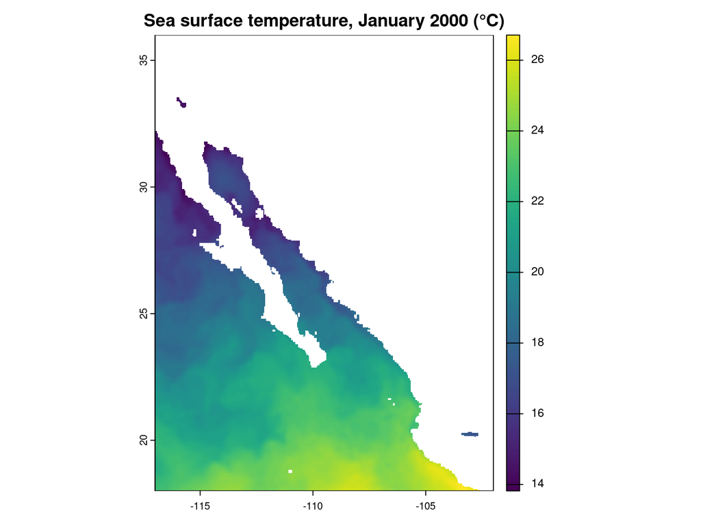

```r
plot(monthly[[1]], main = "Sea surface temperature, January 2000 (°C)")
```

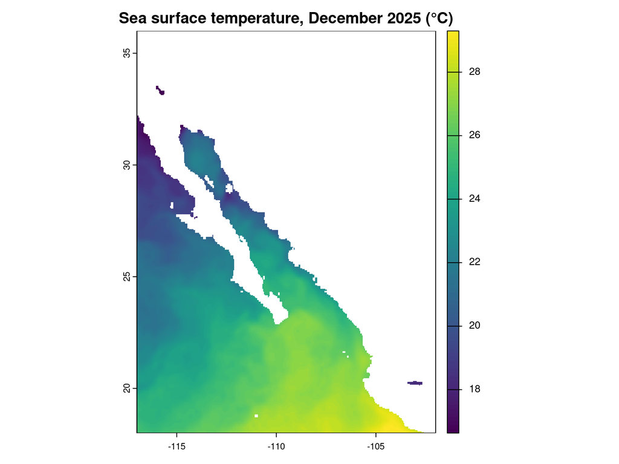

```r
plot(monthly[[nlyr(monthly)]], main = "Sea surface temperature, December 2025 (°C)")
```

January 2000 is a cool month and December 2025 is a warm month. The same land mask is present in every layer. The open Pacific west of Baja and the water south of the Gulf are inside the file and are left out of the regional means by the region polygons in the next section.

## 2. Yearly mean in each marine region

Each OHI region has a land polygon and a marine polygon. Temperature is taken from the marine polygon. A cell that straddles the region boundary is weighted by the fraction of the cell that sits in the water.

The twelve monthly means in a year are averaged with equal weight. That yearly value is what the line is fit to. Twenty-six years, 2000 through 2025, enter the fit.

```r
marine <- st_read(rgn_path, quiet = TRUE) %>%
  st_make_valid() %>%
  filter(location == "marine") %>%
  st_transform(crs(monthly)) %>%
  arrange(rgn_id) %>%
  mutate(label = paste(rgn_id, estado, sep = "\n"))
```

```r
annual <- tapp(monthly, "years", fun = mean, na.rm = TRUE)
names(annual) <- unique(format(time(monthly), "%Y"))
names(annual)
```

```
##  [1] "2000" "2001" "2002" "2003" "2004" "2005" "2006" "2007" "2008" "2009"
## [11] "2010" "2011" "2012" "2013" "2014" "2015" "2016" "2017" "2018" "2019"
## [21] "2020" "2021" "2022" "2023" "2024" "2025"
```

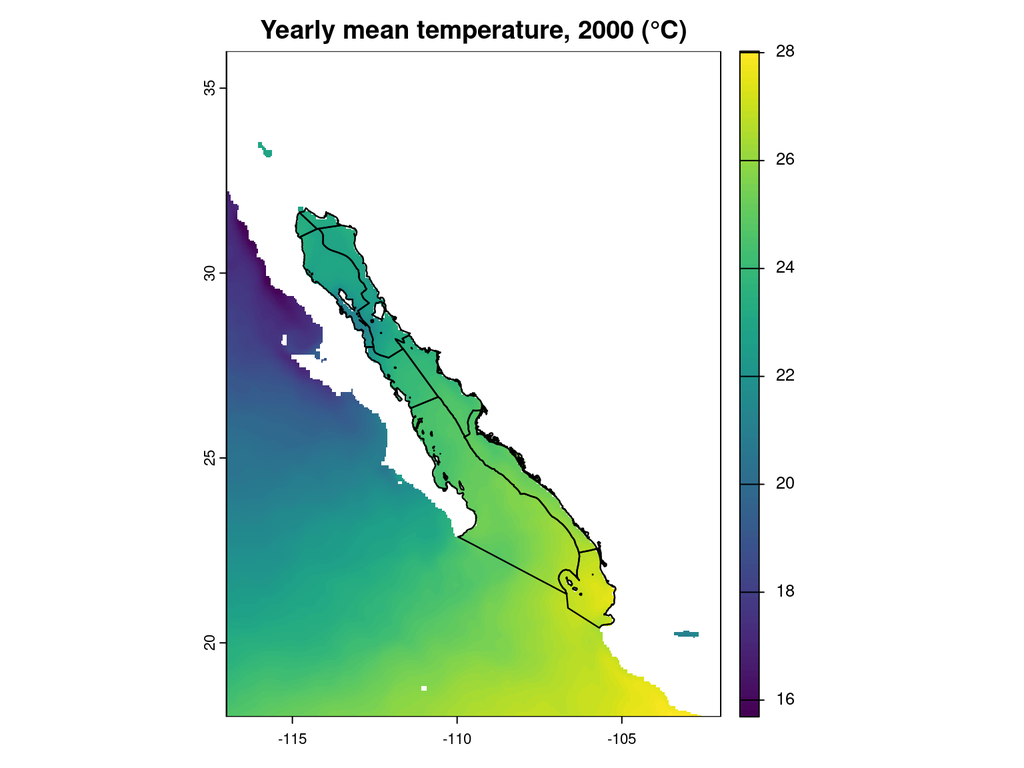

```r
plot(annual[[1]], main = "Yearly mean temperature, 2000 (°C)")
lines(vect(marine), col = "black", lwd = 1.2)
```

The black lines are the nine marine regions. Cells outside those lines stay in the map and stay out of the table.

```r
region_month <- exact_extract(monthly, marine, "mean") %>%
  as_tibble() %>%
  mutate(rgn_id = marine$rgn_id, estado = marine$estado, ecorgn = marine$ecorgn) %>%
  pivot_longer(
    cols = starts_with("mean."),
    names_to = "month",
    names_prefix = "mean.",
    values_to = "sst_c"
  ) %>%
  mutate(year = as.integer(substr(month, 1, 4)))
```

[output not shown]

```r
annual_mean <- region_month %>%
  group_by(rgn_id, estado, ecorgn, year) %>%
  summarise(sst_c = mean(sst_c), .groups = "drop") %>%
  arrange(rgn_id, year)

kable(
  annual_mean %>% filter(year %in% c(2000, 2015, 2025)),
  digits = 2,
  col.names = c("Region", "State", "Ecoregion", "Year", "Mean temperature, °C"),
  caption = "Yearly mean sea surface temperature in three of the twenty-six years"
)
```

Yearly mean sea surface temperature in three of the twenty-six years

| Region | State | Ecoregion | Year | Mean temperature, °C |
| --- | --- | --- | --- | --- |
| Region_1 | Baja_California | Upper_Gulf | 2000 | 23.29 |
| Region_1 | Baja_California | Upper_Gulf | 2015 | 23.83 |
| Region_1 | Baja_California | Upper_Gulf | 2025 | 23.82 |
| Region_2 | Baja_California | Midriff_Region | 2000 | 22.63 |
| Region_2 | Baja_California | Midriff_Region | 2015 | 23.56 |
| Region_2 | Baja_California | Midriff_Region | 2025 | 23.16 |
| Region_3 | Baja_California_Sur | Central_Gulf | 2000 | 23.76 |
| Region_3 | Baja_California_Sur | Central_Gulf | 2015 | 25.00 |
| Region_3 | Baja_California_Sur | Central_Gulf | 2025 | 24.57 |
| Region_4 | Baja_California_Sur | Southern_Gulf | 2000 | 25.31 |
| Region_4 | Baja_California_Sur | Southern_Gulf | 2015 | 26.72 |
| Region_4 | Baja_California_Sur | Southern_Gulf | 2025 | 26.10 |
| Region_5 | Sonora | Upper_Gulf | 2000 | 23.19 |
| Region_5 | Sonora | Upper_Gulf | 2015 | 23.85 |
| Region_5 | Sonora | Upper_Gulf | 2025 | 23.76 |
| Region_6 | Sonora | Midriff_Region | 2000 | 22.85 |
| Region_6 | Sonora | Midriff_Region | 2015 | 24.00 |
| Region_6 | Sonora | Midriff_Region | 2025 | 23.48 |
| Region_7 | Sonora | Central_Gulf | 2000 | 24.19 |
| Region_7 | Sonora | Central_Gulf | 2015 | 25.59 |
| Region_7 | Sonora | Central_Gulf | 2025 | 24.92 |
| Region_8 | Sinaloa | Southern_Gulf | 2000 | 25.34 |
| Region_8 | Sinaloa | Southern_Gulf | 2015 | 26.82 |
| Region_8 | Sinaloa | Southern_Gulf | 2025 | 25.93 |
| Region_9 | Nayarit | Southern_Gulf | 2000 | 27.02 |
| Region_9 | Nayarit | Southern_Gulf | 2015 | 28.23 |
| Region_9 | Nayarit | Southern_Gulf | 2025 | 27.52 |

## 3. Oceanic Niño Index

The index is the NOAA Climate Prediction Center Oceanic Niño Index, from `oni.ascii.txt`. Each row is a three-month season. The season labeled DJF of a year includes December of the year before. The covariate used here is the mean of the twelve seasons labeled with that calendar year. Positive values are El Niño. Negative values are La Niña.

```r
oni_url <- "https://www.cpc.ncep.noaa.gov/data/indices/oni.ascii.txt"
oni_raw_path <- file.path(out_dir, "oni_noaa_cpc.txt")
download.file(oni_url, oni_raw_path, quiet = TRUE)

oni <- read_table(oni_raw_path, show_col_types = FALSE) %>%
  rename(year = YR) %>%
  filter(year %in% unique(annual_mean$year)) %>%
  group_by(year) %>%
  summarise(oni = mean(ANOM), n_seasons = n(), .groups = "drop")

stopifnot(oni$n_seasons == 12)

write_csv(oni %>% select(year, oni), file.path(out_dir, "oni_annual_2000_2025.csv"))
oni
```

```
## # A tibble: 26 × 3
##     year     oni n_seasons
##    <dbl>   <dbl>     <int>
##  1  2000 -0.766         12
##  2  2001 -0.294         12
##  3  2002  0.514         12
##  4  2003  0.235         12
##  5  2004  0.392         12
##  6  2005  0.0292        12
##  7  2006  0.04          12
##  8  2007 -0.613         12
##  9  2008 -0.808         12
## 10  2009  0.259         12
## # ℹ 16 more rows
```

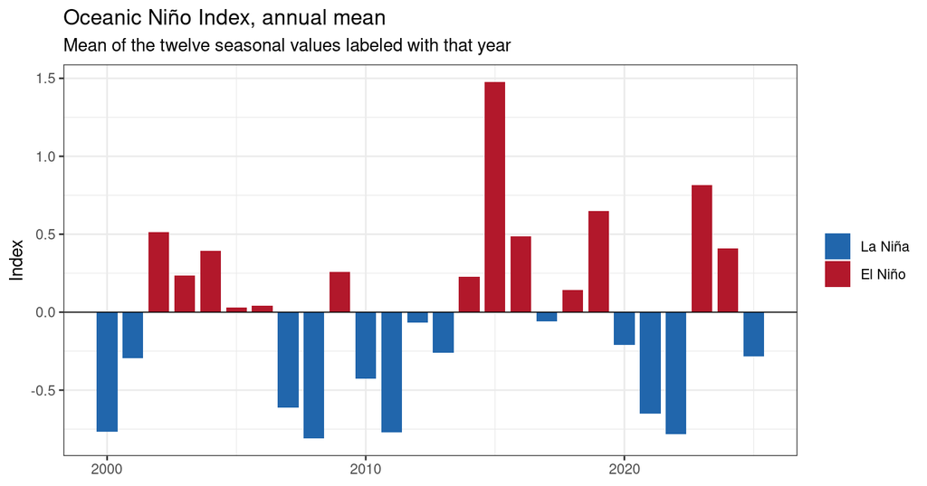

```r
ggplot(oni, aes(year, oni, fill = oni >= 0)) +
  geom_col(width = 0.8) +
  geom_hline(yintercept = 0, linewidth = 0.3) +
  scale_fill_manual(
    values = c("TRUE" = "#b2182b", "FALSE" = "#2166ac"),
    labels = c("TRUE" = "El Niño", "FALSE" = "La Niña"),
    name = NULL
  ) +
  labs(
    title = "Oceanic Niño Index, annual mean",
    subtitle = "Mean of the twelve seasonal values labeled with that year",
    x = NULL,
    y = "Index"
  ) +
  theme_bw()
```

## 4. Average change per year

Each region gets two ordinary linear regressions. The first is temperature on year. The second adds the Niño index. The coefficient on year in the second fit is the saved trend. The coefficient on the index is how many degrees the yearly mean moves for one unit of the index.

```r
fit_trend <- function(df) {
  year_only <- lm(sst_c ~ year, data = df)
  with_oni <- lm(sst_c ~ year + oni, data = df)
  tibble(
    trend_year = coef(year_only)[["year"]],
    trend = coef(with_oni)[["year"]],
    oni_c_per_unit = coef(with_oni)[["oni"]]
  )
}

trends <- annual_mean %>%
  left_join(oni %>% select(year, oni), by = "year") %>%
  group_by(rgn_id, estado, ecorgn) %>%
  group_modify(~ fit_trend(.x)) %>%
  ungroup()

series <- annual_mean %>%
  left_join(oni %>% select(year, oni), by = "year") %>%
  left_join(trends, by = c("rgn_id", "estado", "ecorgn")) %>%
  mutate(
    oni_centered = oni - mean(oni),
    adjusted_c = sst_c - oni_c_per_unit * oni_centered,
    line_year = mean(sst_c) + trend_year * (year - mean(year)),
    line_oni = mean(sst_c) + trend * (year - mean(year)),
    .by = rgn_id
  )

score <- trends %>%
  mutate(year = score_year) %>%
  arrange(rgn_id)

csv_path <- file.path(out_dir, "sst_trend.csv")
write_csv(score %>% select(rgn_id, year, trend), csv_path)

kable(
  score %>%
    transmute(
      rgn_id, estado, ecorgn, year,
      trend_year,
      trend,
      rise_c = trend * (score_year - 2000),
      oni_c_per_unit
    ),
  digits = 3,
  col.names = c(
    "Region", "State", "Ecoregion", "Year",
    "Year only, °C per year", "With Niño index, °C per year",
    "Rise along the saved line, °C", "°C per Niño unit"
  ),
  caption = "The saved trend is the slope on year from the fit that includes the Niño index. The rise is that slope times 25 years."
)
```

The saved trend is the slope on year from the fit that includes the Niño index. The rise is that slope times 25 years.

| Region | State | Ecoregion | Year | Year only, °C per year | With Niño index, °C per year | Rise along the saved line, °C | °C per Niño unit |
| --- | --- | --- | --- | --- | --- | --- | --- |
| Region_1 | Baja_California | Upper_Gulf | 2025 | 0.013 | 0.012 | 0.288 | 0.161 |
| Region_2 | Baja_California | Midriff_Region | 2025 | 0.012 | 0.010 | 0.240 | 0.264 |
| Region_3 | Baja_California_Sur | Central_Gulf | 2025 | 0.018 | 0.013 | 0.331 | 0.450 |
| Region_4 | Baja_California_Sur | Southern_Gulf | 2025 | 0.027 | 0.023 | 0.567 | 0.443 |
| Region_5 | Sonora | Upper_Gulf | 2025 | 0.016 | 0.014 | 0.353 | 0.198 |
| Region_6 | Sonora | Midriff_Region | 2025 | 0.016 | 0.012 | 0.290 | 0.373 |
| Region_7 | Sonora | Central_Gulf | 2025 | 0.019 | 0.014 | 0.346 | 0.488 |
| Region_8 | Sinaloa | Southern_Gulf | 2025 | 0.021 | 0.015 | 0.364 | 0.582 |
| Region_9 | Nayarit | Southern_Gulf | 2025 | 0.022 | 0.016 | 0.402 | 0.524 |

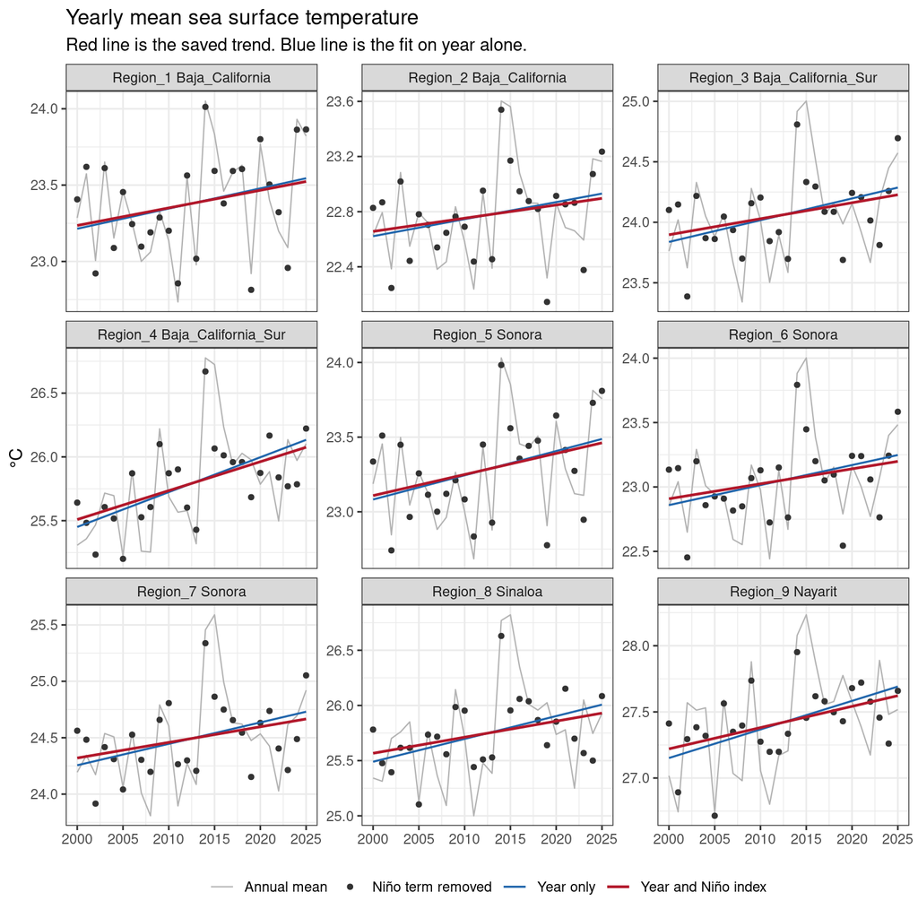

```r
ggplot(series, aes(year)) +
  geom_line(aes(y = sst_c, color = "Annual mean"), linewidth = 0.4) +
  geom_point(aes(y = adjusted_c, color = "Niño term removed"), size = 1.2) +
  geom_line(aes(y = line_year, color = "Year only"), linewidth = 0.6) +
  geom_line(aes(y = line_oni, color = "Year and Niño index"), linewidth = 0.8) +
  scale_color_manual(
    values = c(
      "Annual mean" = "grey70",
      "Niño term removed" = "grey20",
      "Year only" = "#2166ac",
      "Year and Niño index" = "#b2182b"
    ),
    breaks = c("Annual mean", "Niño term removed", "Year only", "Year and Niño index"),
    name = NULL
  ) +
  facet_wrap(~ paste(rgn_id, estado), scales = "free_y", ncol = 3) +
  labs(
    title = "Yearly mean sea surface temperature",
    subtitle = "Red line is the saved trend. Blue line is the fit on year alone.",
    x = NULL,
    y = "°C"
  ) +
  theme_bw() +
  theme(legend.position = "bottom")
```

The grey line is the yearly mean. The points are that mean with the Niño term taken off, so an El Niño year is moved down and a La Niña year is moved up. The blue line is the slope on year alone. The red line is the slope on year from the fit that includes the index, drawn through the same average temperature. That red slope is the saved trend.

2014 is the hot point that remains after the Niño term is removed. The index that year is about 0.23, a weak El Niño, while 2015 is the strong event, with an index of about 1.5. The index accounts for 2015. It does not account for 2014, which was a marine heatwave. That year also sits near the middle of 2000–2025, so it lifts the line and barely tilts it. Leaving 2014 out changes the saved slope by less than 0.001°C per year. The saved trend keeps every year.

```r
without_2014 <- annual_mean %>%
  filter(year != 2014) %>%
  left_join(oni %>% select(year, oni), by = "year") %>%
  group_by(rgn_id) %>%
  group_modify(~ tibble(trend_without_2014 = coef(lm(sst_c ~ year + oni, data = .x))[["year"]])) %>%
  ungroup()

kable(
  score %>%
    select(rgn_id, trend) %>%
    left_join(without_2014, by = "rgn_id") %>%
    mutate(difference = trend_without_2014 - trend),
  digits = 4,
  col.names = c("Region", "All years", "Without 2014", "Difference"),
  caption = "Saved trend compared with the same fit after 2014 is left out. Both slopes include the Niño index."
)
```

Saved trend compared with the same fit after 2014 is left out. Both slopes include the Niño index.

| Region | All years | Without 2014 | Difference |
| --- | --- | --- | --- |
| Region_1 | 0.0115 | 0.0111 | -5e-04 |
| Region_2 | 0.0096 | 0.0090 | -6e-04 |
| Region_3 | 0.0132 | 0.0127 | -6e-04 |
| Region_4 | 0.0227 | 0.0220 | -6e-04 |
| Region_5 | 0.0141 | 0.0136 | -5e-04 |
| Region_6 | 0.0116 | 0.0111 | -5e-04 |
| Region_7 | 0.0138 | 0.0132 | -6e-04 |
| Region_8 | 0.0145 | 0.0139 | -7e-04 |
| Region_9 | 0.0161 | 0.0157 | -4e-04 |

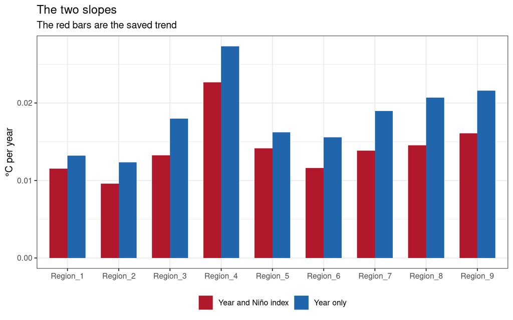

```r
compare <- score %>%
  select(rgn_id, `Year only` = trend_year, `Year and Niño index` = trend) %>%
  pivot_longer(-rgn_id, names_to = "fit", values_to = "trend")

ggplot(compare, aes(rgn_id, trend, fill = fit)) +
  geom_col(position = "dodge", width = 0.7) +
  scale_fill_manual(values = c("Year only" = "#2166ac", "Year and Niño index" = "#b2182b"), name = NULL) +
  labs(
    title = "The two slopes",
    subtitle = "The red bars are the saved trend",
    x = NULL,
    y = "°C per year"
  ) +
  theme_bw() +
  theme(legend.position = "bottom")
```

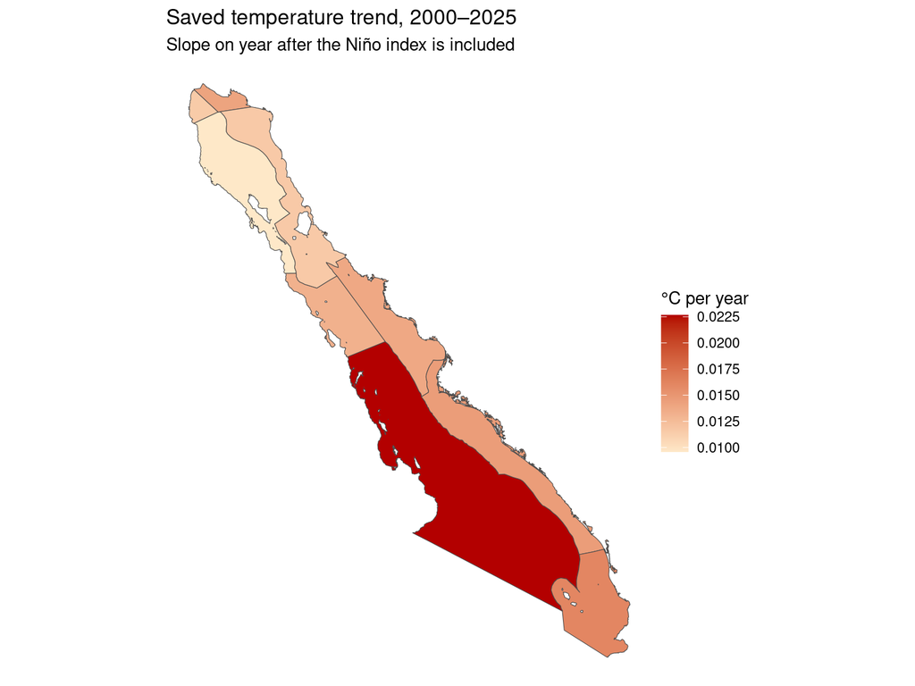

```r
trend_map <- marine %>%
  left_join(score %>% select(rgn_id, trend), by = "rgn_id")

ggplot(trend_map) +
  geom_sf(aes(fill = trend), color = "grey30", linewidth = 0.2) +
  scale_fill_gradient(low = "#fee8c8", high = "#b30000", name = "°C per year") +
  labs(
    title = "Saved temperature trend, 2000–2025",
    subtitle = "Slope on year after the Niño index is included"
  ) +
  theme_void()
```

## 5. The same line in every ocean cell

The regional slope is the area-weighted mean of the cell slopes, because every ocean cell is present in every month and the Niño index is the same series in every cell. Fitting the cells makes the pattern inside a region visible. The equation in each cell is the saved one:

temperature = intercept + (trend × year) + (El Niño term × Oceanic Niño Index)

```r
year_index <- as.integer(names(annual))
oni_for_cells <- oni %>%
  filter(year %in% year_index) %>%
  arrange(year)
stopifnot(oni_for_cells$year == year_index)

design <- model.matrix(
  ~ year + oni,
  data = tibble(year = year_index, oni = oni_for_cells$oni)
)
cell_values <- values(annual)
keep <- complete.cases(cell_values)
beta <- qr.coef(qr(design), t(cell_values[keep, , drop = FALSE]))

trend_values <- rep(NA_real_, ncell(annual))
trend_values[keep] <- beta["year", ]
cell_trend <- setValues(annual[[1]], trend_values)
names(cell_trend) <- "trend_c_per_year"

cell_trend <- mask(cell_trend, vect(st_union(marine)))
trend_path <- file.path(out_dir, "sst_cell_trend.tif")
writeRaster(cell_trend, trend_path, overwrite = TRUE)

cell_mean <- exact_extract(cell_trend, marine, "mean")
```

[output not shown]

```r
kable(
  score %>%
    transmute(rgn_id, regional_fit = trend, mean_of_cells = cell_mean) %>%
    mutate(difference = mean_of_cells - regional_fit),
  digits = 4,
  col.names = c("Region", "Fit to the regional mean", "Mean of the cell slopes", "Difference"),
  caption = "The two routes to the regional trend. The difference is rounding."
)
```

The two routes to the regional trend. The difference is rounding.

| Region | Fit to the regional mean | Mean of the cell slopes | Difference |
| --- | --- | --- | --- |
| Region_1 | 0.0115 | 0.0115 | 0 |
| Region_2 | 0.0096 | 0.0096 | 0 |
| Region_3 | 0.0132 | 0.0132 | 0 |
| Region_4 | 0.0227 | 0.0227 | 0 |
| Region_5 | 0.0141 | 0.0141 | 0 |
| Region_6 | 0.0116 | 0.0116 | 0 |
| Region_7 | 0.0138 | 0.0138 | 0 |
| Region_8 | 0.0145 | 0.0145 | 0 |
| Region_9 | 0.0161 | 0.0161 | 0 |

Mangrove is the Hem mangrove classes. The coastal wetland is the 2021 saltmarsh, dune, and dry-salt-scrub classes, kept within 5 km of the marine regions, which is the same wetland layer used for the aquaculture pressure.

```r
mangrove_classes <- c(
  "MANGLAR",
  "VEGETACIÓN SECUNDARIA ARBÓREA DE MANGLAR",
  "VEGETACIÓN SECUNDARIA ARBUSTIVA DE MANGLAR",
  "VEGETACIÓN SECUNDARIA HERBÁCEA DE MANGLAR"
)
mangrove <- st_read(
  "/home/shares/ohi/OHI_GOC/_raw_data/mangrove_Hem/USV_AGRUPADO/USV_AGRUPADO.shp",
  quiet = TRUE
) %>%
  filter(DESCRIP_AG %in% mangrove_classes) %>%
  st_make_valid() %>%
  st_transform(crs(cell_trend)) %>%
  st_crop(st_bbox(marine))

wetland_classes <- c(
  "VEGETACIÓN HALÓFILA HIDRÓFILA",
  "VEGETACIÓN SECUNDARIA ARBUSTIVA DE VEGETACIÓN HALÓFILA HIDRÓFILA",
  "VEGETACIÓN DE DUNAS COSTERAS",
  "VEGETACIÓN HALÓFILA XERÓFILA",
  "VEGETACIÓN SECUNDARIA ARBUSTIVA DE VEGETACIÓN HALÓFILA XERÓFILA"
)
quoted_classes <- paste0("'", wetland_classes, "'", collapse = ", ")
marine_lcc <- st_read(rgn_path, quiet = TRUE) %>%
  st_make_valid() %>%
  filter(location == "marine") %>%
  st_union()
wetland_zone <- st_buffer(marine_lcc, 5000) %>%
  st_transform(crs(cell_trend))
wetland <- st_read(
  "/home/shares/ohi/OHI_GOC/_raw_data/CONABIO_Saltmarsh_landuse_veg/usv250s7gw/usv250s7gw.shp",
  query = sprintf(
    "SELECT * FROM \"usv250s7gw\" WHERE DESCRIPCIO IN (%s)",
    quoted_classes
  ),
  quiet = TRUE
) %>%
  st_transform(crs(cell_trend)) %>%
  st_make_valid() %>%
  st_crop(st_bbox(marine)) %>%
  st_intersection(wetland_zone)
```

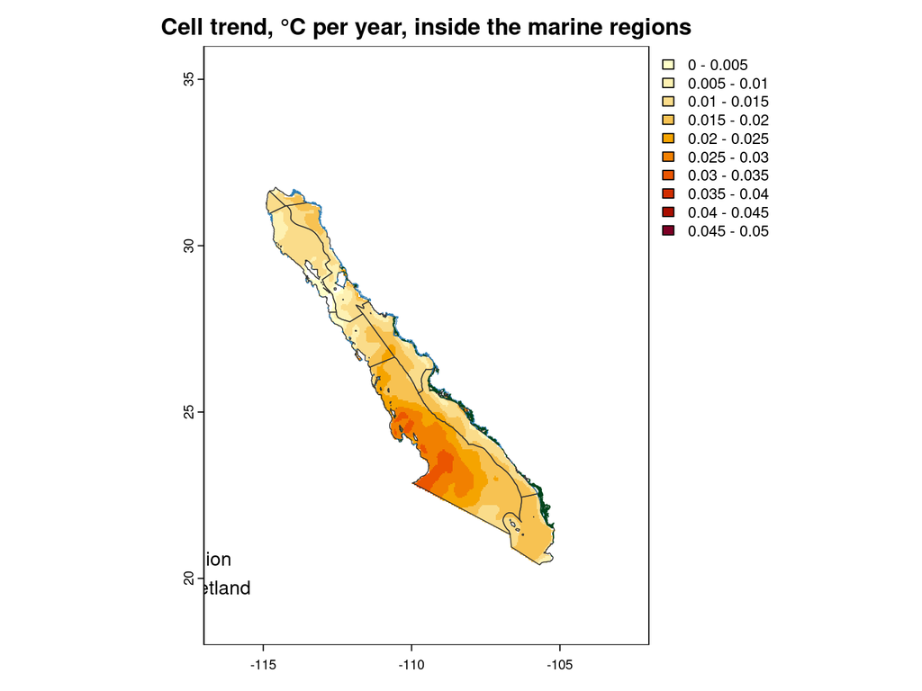

```r
breaks <- seq(0, 0.05, by = 0.005)
colors <- hcl.colors(length(breaks) - 1, "YlOrRd", rev = TRUE)
plot(
  cell_trend,
  breaks = breaks,
  col = colors,
  main = "Cell trend, °C per year, inside the marine regions"
)
lines(vect(marine), col = "grey20", lwd = 0.8)
lines(vect(st_union(wetland)), col = "#2c7fb8", lwd = 0.6)
lines(vect(st_union(mangrove)), col = "#00441b", lwd = 0.7)
legend(
  "bottomleft",
  legend = c("Marine region", "Coastal wetland", "Mangrove"),
  col = c("grey20", "#2c7fb8", "#00441b"),
  lwd = 1.5,
  bty = "n"
)
```

Yellow is a smaller increase and red is a larger one. Values above 0.05°C per year are drawn in the top color. The blue line is the coastal wetland. The dark green line is mangrove. Both sit on the water next to the coast, so the color under those lines is the trend in the cells those habitats face.

## 6. Pressure

The rise is the saved trend times 25, the change along the line from 2000 to 2025. The pressure divides that rise by 1°C and holds the result between 0 and 1. The same rescaling is applied to every ocean cell. The cell trend raster is the raw slope, in °C per year. The cell pressure raster is that slope times 25, divided by 1°C.

One degree of sea-surface increase is the warming associated with a 2°C increase in global temperature, the higher end of the Paris Agreement. Cael and coauthors report a global mean sea-surface rise of 0.91°C, and a rise in the annual maximum of 1.07°C, between 1982–2020 and the decades centered on 2°C of global warming. The reference here rounds the mean rise to 1°C. [Cael et al. 2024, Science Advances](https://doi.org/10.1126/sciadv.adj5569).

```r
reference_c <- 1

pressure <- score %>%
  mutate(
    rise_c = trend * (score_year - 2000),
    pressure = round(pmin(pmax(rise_c / reference_c, 0), 1), 2)
  ) %>%
  arrange(rgn_id)

pressure_path <- file.path(out_dir, "sst_pressure.csv")
write_csv(
  pressure %>% transmute(rgn_id, year, pressure = sprintf("%.2f", pressure)),
  pressure_path
)

kable(
  pressure %>%
    select(rgn_id, estado, ecorgn, year, rise_c, pressure) %>%
    mutate(pressure = sprintf("%.2f", pressure)),
  digits = 3,
  col.names = c(
    "Region", "State", "Ecoregion", "Year",
    "Rise, °C", "Pressure"
  ),
  caption = "Pressure = rise since 2000 / 1°C, held between 0 and 1. A 1°C sea-surface rise is the warming associated with 2°C of global warming, the higher end of the Paris Agreement (Cael et al. 2024)."
)
```

Pressure = rise since 2000 / 1°C, held between 0 and 1. A 1°C sea-surface rise is the warming associated with 2°C of global warming, the higher end of the Paris Agreement (Cael et al. 2024).

| Region | State | Ecoregion | Year | Rise, °C | Pressure |
| --- | --- | --- | --- | --- | --- |
| Region_1 | Baja_California | Upper_Gulf | 2025 | 0.288 | 0.29 |
| Region_2 | Baja_California | Midriff_Region | 2025 | 0.240 | 0.24 |
| Region_3 | Baja_California_Sur | Central_Gulf | 2025 | 0.331 | 0.33 |
| Region_4 | Baja_California_Sur | Southern_Gulf | 2025 | 0.567 | 0.57 |
| Region_5 | Sonora | Upper_Gulf | 2025 | 0.353 | 0.35 |
| Region_6 | Sonora | Midriff_Region | 2025 | 0.290 | 0.29 |
| Region_7 | Sonora | Central_Gulf | 2025 | 0.346 | 0.35 |
| Region_8 | Sinaloa | Southern_Gulf | 2025 | 0.364 | 0.36 |
| Region_9 | Nayarit | Southern_Gulf | 2025 | 0.402 | 0.40 |

```r
cell_pressure_values <- as.numeric(values(cell_trend)) * (score_year - 2000) / reference_c
cell_pressure_values[!is.finite(cell_pressure_values)] <- NA_real_
cell_pressure_values <- round(pmin(pmax(cell_pressure_values, 0), 1), 2)

cell_pressure <- setValues(cell_trend, cell_pressure_values)
names(cell_pressure) <- "pressure"

pressure_tif_path <- file.path(out_dir, "sst_cell_pressure.tif")
writeRaster(cell_pressure, pressure_tif_path, overwrite = TRUE)
```

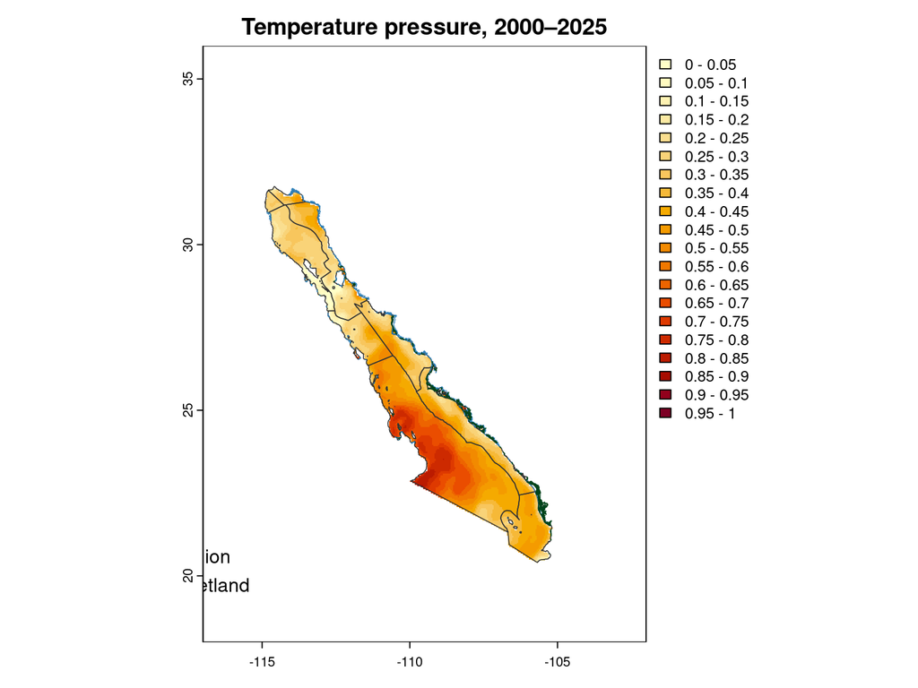

```r
pressure_breaks <- seq(0, 1, by = 0.05)
pressure_colors <- hcl.colors(length(pressure_breaks) - 1, "YlOrRd", rev = TRUE)
plot(
  cell_pressure,
  breaks = pressure_breaks,
  col = pressure_colors,
  main = "Temperature pressure, 2000–2025"
)
lines(vect(marine), col = "grey20", lwd = 0.8)
lines(vect(st_union(wetland)), col = "#2c7fb8", lwd = 0.6)
lines(vect(st_union(mangrove)), col = "#00441b", lwd = 0.7)
legend(
  "bottomleft",
  legend = c("Marine region", "Coastal wetland", "Mangrove"),
  col = c("grey20", "#2c7fb8", "#00441b"),
  lwd = 1.5,
  bty = "n"
)
```

Pale yellow is a small rise relative to 1°C. Red is a rise that reaches 1°C. The same wetland and mangrove lines are drawn on top.

The trend table is /home/frazier/ohi_goc_prep/_pressures/prs_sst/v2025/output/sst_trend.csv. The pressure table is /home/frazier/ohi_goc_prep/_pressures/prs_sst/v2025/output/sst_pressure.csv, with `rgn_id`, `year`, and `pressure`. The cell trend, in °C per year, is /home/frazier/ohi_goc_prep/_pressures/prs_sst/v2025/output/sst_cell_trend.tif. The rescaled cell pressure is /home/frazier/ohi_goc_prep/_pressures/prs_sst/v2025/output/sst_cell_pressure.tif.